# Assignment 1 - Data analysis 2

# Executive summary

I set out to analyse the pattern of association between the number of confirmed COVID cases and the number of deaths caused by COVID-19 in all countries where this data is available. I used log-log transformation and scaled the number of confirmed and fallen people by the population of each country to arrive to 'per capita' variables. I used regression analysis to uncover these tendencies, and found in my sample for the 15th Oct, 2020 that there is a positive association between the two variables. The main message my model wishes to convey is that understanding the number of people contracted by the virus is crucially important for governments, so that they can have an expectation as to how many people might die due to the disease. On the one hand my results could have been strengthened by including more variables such as the age of people (or a categorical variable representing age groups) to see whether the virus is deadlier for the older population. My results, on the other hand could have been weakend by using level instead of log variables, as it was quite apparent in the EDA phase that without ln transformation my R<sup>2</sup> would have dropped approximately to the half of what I was able to achieve with my final model.

# Appendix

### Transforming variables

The below is to show why log-log model was the best choice when deciding on transformation of variables.

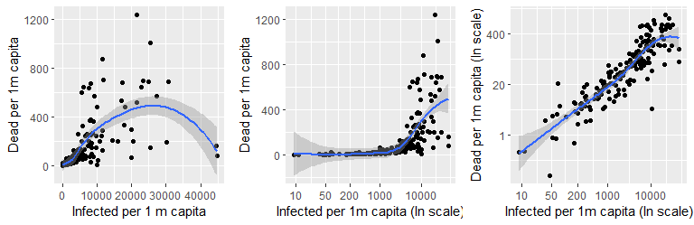

### Model Comparison and model choice

The below table and scatter plots serve as summary for four regression models that I run in order to uncover the pattern of association between my log transformed $x$ and $y$ variables. The models were ther following:

- **Model 1** - simple linear regression
- **Model 2** - a quadratic regression
- **Model 3** - piecewise linear spline with two cutoffs that I determined by looking at the lowess function which is also visible in Figure 2
- **Model 4** - weighted regression where the weight was the population of a country

Modeling Covid-19 caused deaths and confirmed cases

|  | Confirmed/capita - linear | Confirmed/capita - quadratic | Confirmed/capita - PLS | Confirmed/capita - weighted linear |
| --- | --- | --- | --- | --- |
| (Intercept) | -3.42* | -3.06* | -2.67* | -2.91* |
|  | [-4.11; -2.73] | [-4.95; -1.16] | [-4.36; -0.97] | [-4.20; -1.62] |
| ln_conf_pc | 0.93* | 0.82* |  | 0.90* |
|  | [ 0.84; 1.02] | [ 0.29; 1.35] |  | [ 0.74; 1.06] |
| ln_conf_pc_sq |  | 0.01 |  |  |
|  |  | [-0.03; 0.04] |  |  |
| lspline(ln_conf_pc, ln_cutoff)1 |  |  | 0.77* |  |
|  |  |  | [ 0.45; 1.09] |  |
| lspline(ln_conf_pc, ln_cutoff)2 |  |  | 0.97* |  |
|  |  |  | [ 0.81; 1.13] |  |
| lspline(ln_conf_pc, ln_cutoff)3 |  |  | 0.94* |  |
|  |  |  | [ 0.68; 1.20] |  |
| R<sup>2</sup> | 0.79 | 0.79 | 0.79 | 0.90 |
| Adj. R<sup>2</sup> | 0.79 | 0.79 | 0.79 | 0.90 |
| Num. obs. | 168 | 168 | 168 | 168 |
| RMSE | 0.83 | 0.83 | 0.83 | 4176.82 |

* Null hypothesis value outside the confidence interval.

All the above models estimated a positive trend in our sample indicating that the log number of death per 1 million capita is higher for higher log number of confirmed cases per 1m capita. All models showed a very good fit, with R<sup>2</sup> being 0.79 in the first 3 models and 0.9 for the last one. In Model 4 we can see that countries with bigger population (indicated with bigger size for the dots) are very close to the trend line, which is probably the reason why the fit was much better. However weighting is not really sensible, since we already examine per capita variables. The estimated slope parameters were significant at 5% in every case, except the squared parameter for the quadratic case. We can also see from the scatter plots that the relationship is closer to linear, than non-linear, so probably not even higher order polynomials would provide a much better fit. From the looks of it, the dots are also spread around the estimated $\hat{y}$ variables in a quite symmetric, seemingly homoskedastic manner.

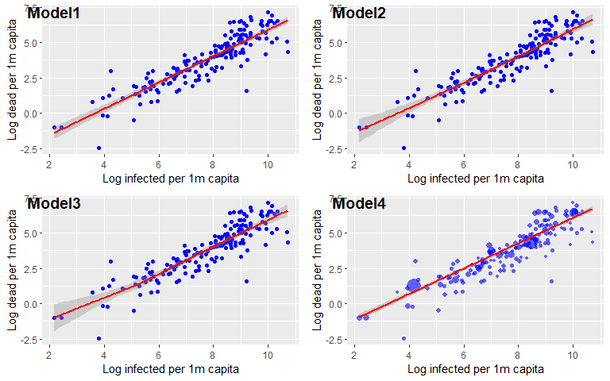

Scatter plots with regression models visualised for confirmed and died COVID-19 cases for 15th Oct, 2020

For my analysis I chose **Model 1**, the simple linear regression. The pattern of association in the data clearly indicates a linear relationship between the log number of confirmed cases per 1m capita and log deaths per 1m capita. This linear pattern is also understood between virologist and other experts - if someone contracts this disease, there is a possibility that it kills them. In addition to that, regression estimates in the simple case are the easiest to translate.